# Jan 31 2018

## packages

```r
library(MASS)
library(tidyverse)
library(nnet)
```

## Miners data

Aligned in columns:

```r
my_url="http://www.utsc.utoronto.ca/~butler/d29/miners-tab.txt"
freqs=read_table(my_url)
freqs
```

| Exposure | None | Moderate | Severe |
| --- | --- | --- | --- |
| 5.8 | 98 | 0 | 0 |
| 15.0 | 51 | 2 | 1 |
| 21.5 | 34 | 6 | 3 |
| 27.5 | 35 | 5 | 8 |
| 33.5 | 32 | 10 | 9 |
| 39.5 | 23 | 7 | 8 |
| 46.0 | 12 | 6 | 10 |
| 51.5 | 4 | 2 | 5 |

Not tidy: want *one* column of frequencies. Add a column of row proportions.

```r
miners = freqs %>%
  gather(Severity,Freq,None:Severe) %>%
  group_by(Exposure) %>%
  mutate(proportion=prop.table(Freq)) %>%
  ungroup()
miners
```

| Exposure | Severity | Freq | proportion |
| --- | --- | --- | --- |
| 5.8 | None | 98 | 1.00000000 |
| 15.0 | None | 51 | 0.94444444 |
| 21.5 | None | 34 | 0.79069767 |
| 27.5 | None | 35 | 0.72916667 |
| 33.5 | None | 32 | 0.62745098 |
| 39.5 | None | 23 | 0.60526316 |
| 46.0 | None | 12 | 0.42857143 |
| 51.5 | None | 4 | 0.36363636 |
| 5.8 | Moderate | 0 | 0.00000000 |
| 15.0 | Moderate | 2 | 0.03703704 |

[output cut: 14 more lines]

Plot proportions in each disease category against exposure:

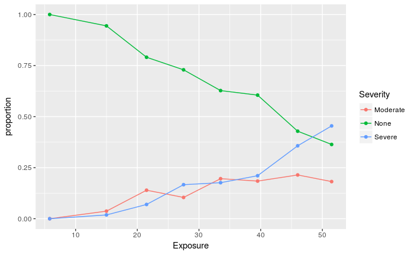

```r
ggplot(miners,aes(x=Exposure,y=proportion,
    colour=Severity))+geom_point()+geom_line()
```

Problem: severity categories *in wrong order*. For modelling, need in correct order. Fix that now (and get improved plot). First, get different severity categories:

```r
v=unique(miners$Severity)
v
```

```
[1] "None"     "Moderate" "Severe"
```

These happen to be in right order (the order they were in data file). A more `tidyverse` way:

```r
miners %>% distinct(Severity)
```

| Severity |
| --- |
| None |
| Moderate |
| Severe |

only this is a data frame and we want vector, so:

```r
v2 = miners %>% distinct(Severity) %>% pull(Severity)
v2
```

```
[1] "None"     "Moderate" "Severe"
```

Now created **ordered factor** with categories in specified order:

```r
miners = miners %>%
    mutate(sev_ord=ordered(Severity,v))
miners
```

| Exposure | Severity | Freq | proportion | sev_ord |
| --- | --- | --- | --- | --- |
| 5.8 | None | 98 | 1.00000000 | None |
| 15.0 | None | 51 | 0.94444444 | None |
| 21.5 | None | 34 | 0.79069767 | None |
| 27.5 | None | 35 | 0.72916667 | None |
| 33.5 | None | 32 | 0.62745098 | None |
| 39.5 | None | 23 | 0.60526316 | None |
| 46.0 | None | 12 | 0.42857143 | None |
| 51.5 | None | 4 | 0.36363636 | None |
| 5.8 | Moderate | 0 | 0.00000000 | Moderate |
| 15.0 | Moderate | 2 | 0.03703704 | Moderate |

[output cut: 14 more lines]

Note the `ord`.

If you wanted the levels to be in a different order from how they appear in v:

```r
v
```

```
[1] "None"     "Moderate" "Severe"
```

say, severe, moderate, none, you use the square bracket thing to choose them in the right order:

```r
miners %>%
  mutate(w=ordered(Severity,v[c(3,2,1)])) %>%
  pull(w)
```

```
 [1] None     None     None     None     None     None     None     None     Moderate Moderate Moderate Moderate Moderate Moderate Moderate Moderate Severe   Severe   Severe   Severe   Severe   Severe
[23] Severe   Severe
Levels: Severe < Moderate < None
```

which here is logically backwards, but shows the procedure.

Now redraw plot. Change is to use ordered factor as `colour`:

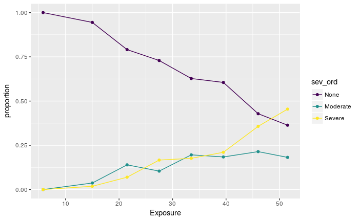

```r
ggplot(miners,aes(x=Exposure,y=proportion,
    colour=sev_ord))+geom_point()+geom_line()
```

## Ordered logistic regression

There seems to be effect of exposure, so model it:

```r
sev.1=polr(sev_ord~Exposure,weights=Freq,
              data=miners)
summary(sev.1)
```

```
Re-fitting to get Hessian
```

```
Call:
polr(formula = sev_ord ~ Exposure, data = miners, weights = Freq)

Coefficients:
          Value Std. Error t value
Exposure 0.0959    0.01194   8.034

Intercepts:
                Value   Std. Error t value
None|Moderate    3.9558  0.4097     9.6558
Moderate|Severe  4.8690  0.4411    11.0383

Residual Deviance: 416.9188
AIC: 422.9188
```

Summary not very helpful.

Two ways to assess effect of exposure:

1. use `drop1` to see whether we can drop it from the model:

```r
drop1(sev.1,test="Chisq")
```

```
Single term deletions

Model:
sev_ord ~ Exposure
         Df    AIC    LRT  Pr(>Chi)
<none>      422.92
Exposure  1 509.16 88.243 < 2.2e-16 ***
---
Signif. codes:  0 ‘***’ 0.001 ‘**’ 0.01 ‘*’ 0.05 ‘.’ 0.1 ‘ ’ 1
```

Story: no we can’t.

2. use `anova`. Fit model without `exposure`, and compare fits. `~1` is model with just intercept (no x’s):

```r
sev.0=polr(sev_ord~1,weights=Freq,data=miners)
anova(sev.0,sev.1)
```

```
Likelihood ratio tests of ordinal regression models

Response: sev_ord
     Model Resid. df Resid. Dev   Test    Df LR stat. Pr(Chi)
1        1       369   505.1621
2 Exposure       368   416.9188 1 vs 2     1 88.24324       0
```

Likewise, need the bigger model with `Exposure` in it, since it fits significantly better.

Another way is `update`:

```r
sev.0a=update(sev.1,.~.-Exposure)
anova(sev.0a,sev.1)
```

```
Likelihood ratio tests of ordinal regression models

Response: sev_ord
     Model Resid. df Resid. Dev   Test    Df LR stat. Pr(Chi)
1        1       369   505.1621
2 Exposure       368   416.9188 1 vs 2     1 88.24324       0
```

Same.

Usual way to understand effects of explanatory variables: do predictions. Let’s predict for all exposures in original data set. Get all these exposures first:

```r
sev.new = freqs %>% select(Exposure)
sev.new
```

| Exposure |
| --- |
| 5.8 |
| 15.0 |
| 21.5 |
| 27.5 |
| 33.5 |
| 39.5 |
| 46.0 |
| 51.5 |

then do predictions:

```r
pr=predict(sev.1,sev.new,type="probs")
miners.pred=cbind(sev.new,pr)
miners.pred
```

|  | Exposure | None | Moderate | Severe |
| --- | --- | --- | --- | --- |
| 1 | 5.8 | 0.9676920 | 0.01908912 | 0.01321885 |
| 2 | 15.0 | 0.9253445 | 0.04329931 | 0.03135614 |
| 3 | 21.5 | 0.8692003 | 0.07385858 | 0.05694115 |
| 4 | 27.5 | 0.7889290 | 0.11413004 | 0.09694093 |
| 5 | 33.5 | 0.6776641 | 0.16207145 | 0.16026444 |
| 6 | 39.5 | 0.5418105 | 0.20484198 | 0.25334756 |
| 7 | 46.0 | 0.3879962 | 0.22441555 | 0.38758828 |
| 8 | 51.5 | 0.2722543 | 0.21025011 | 0.51749563 |

## Plotting the predictions

Need all the predictions in one column:

```r
preds = miners.pred %>%
  gather(Severity,probability,None:Severe)
preds
```

| Exposure | Severity | probability |
| --- | --- | --- |
| 5.8 | None | 0.96769203 |
| 15.0 | None | 0.92534455 |
| 21.5 | None | 0.86920028 |
| 27.5 | None | 0.78892903 |
| 33.5 | None | 0.67766411 |
| 39.5 | None | 0.54181046 |
| 46.0 | None | 0.38799618 |
| 51.5 | None | 0.27225426 |
| 5.8 | Moderate | 0.01908912 |
| 15.0 | Moderate | 0.04329931 |

[output cut: 14 more lines]

Plot predictions joined by lines *and* observed proportions (as points):

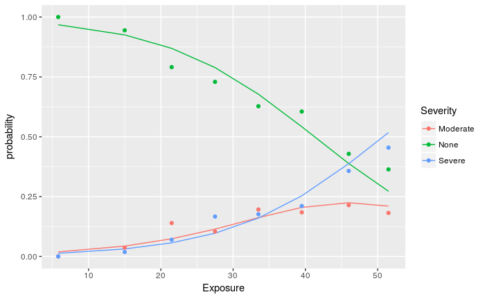

```r
ggplot(preds,aes(x=Exposure,y=probability,
  colour=Severity)) + geom_line() +
  geom_point(data=miners,aes(y=proportion))
```

Agreement between data (points) and model (curves) is pretty good. More exposure goes with a higher change of more disease, so association with disease is a positive one.

## When the response categories are not ordered

Read in some data:

```r
my_url="http://www.utsc.utoronto.ca/~butler/d29/mlogit.csv"
brandpref=read_csv(my_url)
brandpref
```

| brand | sex | age |
| --- | --- | --- |
| 1 | 0 | 24 |
| 1 | 0 | 26 |
| 1 | 0 | 26 |
| 1 | 1 | 27 |
| 1 | 1 | 27 |
| 3 | 1 | 27 |
| 1 | 0 | 27 |
| 1 | 0 | 27 |
| 1 | 1 | 27 |
| 1 | 0 | 27 |

[output cut: 725 more lines]

735 people (one per row) expressed which of three brands of a product they preferred. Also recorded was person’s age and sex (0=male, 1=female). Do age and/or sex predict preferred brand?

Brand and sex are really categorical variables expressed as numbers, so turn into factors:

```r
brandpref = brandpref %>%
    mutate(sex=factor(sex)) %>%
    mutate(brand=factor(brand))
brandpref
```

| brand | sex | age |
| --- | --- | --- |
| 1 | 0 | 24 |
| 1 | 0 | 26 |
| 1 | 0 | 26 |
| 1 | 1 | 27 |
| 1 | 1 | 27 |
| 3 | 1 | 27 |
| 1 | 0 | 27 |
| 1 | 0 | 27 |
| 1 | 1 | 27 |
| 1 | 0 | 27 |

[output cut: 725 more lines]

Values 1-3 for `brand` are just labels for different brands. **No ordering**. `brand` is “nominal”. Compare miners (where severity of disease was ordered). Here, need a “multinomial” model, such as `multinom` from `nnet`:

```r
brands.1=multinom(brand~age+sex,data=brandpref)
```

Again, looking at output not helpful:

```r
summary(brands.1)
```

```
Call:
multinom(formula = brand ~ age + sex, data = brandpref)

Coefficients:
  (Intercept)       age      sex1
2   -11.77469 0.3682075 0.5238197
3   -22.72141 0.6859087 0.4659488

Std. Errors:
  (Intercept)        age      sex1
2    1.774614 0.05500320 0.1942467
3    2.058030 0.06262657 0.2260895

Residual Deviance: 1405.941
AIC: 1417.941
```

Search for a good model first (then think about predictions). Can we drop either explanatory variable? `drop1`:

```r
drop1(brands.1,test="Chisq")
```

```
trying - age
```

```
Error in if (trace) { : argument is not interpretable as logical
```

Doesn’t work. So have to fit models without `age` and `sex` and compare fit with `anova`:

```r
brands.2=multinom(brand~age,data=brandpref)
brands.3=multinom(brand~sex,data=brandpref)
anova(brands.2,brands.1)
```

```
Likelihood ratio tests of Multinomial Models

Response: brand
      Model Resid. df Resid. Dev   Test    Df LR stat.    Pr(Chi)
1       age      1466   1413.593
2 age + sex      1464   1405.941 1 vs 2     2 7.651236 0.02180495
```

```r
anova(brands.3,brands.1)
```

```
Likelihood ratio tests of Multinomial Models

Response: brand
      Model Resid. df Resid. Dev   Test    Df LR stat. Pr(Chi)
1       sex      1466   1583.723
2 age + sex      1464   1405.941 1 vs 2     2 177.7811       0
```

Both `age` and `sex` have to stay.

Curiously, `step` works:

```r
step(brands.1)
```

```
Start:  AIC=1417.94
brand ~ age + sex

trying - age
trying - sex
       Df      AIC
<none>  6 1417.941
- sex   4 1421.593
- age   4 1591.723
Call:
multinom(formula = brand ~ age + sex, data = brandpref)

Coefficients:
  (Intercept)       age      sex1
2   -11.77469 0.3682075 0.5238197
3   -22.72141 0.6859087 0.4659488

Residual Deviance: 1405.941
AIC: 1417.941
```

Same conclusion: both `age` and `sex` have to stay in model.

## Predictions

Some combinations of age and sex:

```r
ages=c(24,28,32,35,38)
sexes=factor(0:1)
new=crossing(age=ages,sex=sexes)
new
```

| age | sex |
| --- | --- |
| 24 | 0 |
| 24 | 1 |
| 28 | 0 |
| 28 | 1 |
| 32 | 0 |
| 32 | 1 |
| 35 | 0 |
| 35 | 1 |
| 38 | 0 |
| 38 | 1 |

Predict:

```r
p=predict(brands.1,new,type="probs")
probs=cbind(new,p)
probs
```

|  | age | sex | 1 | 2 | 3 |
| --- | --- | --- | --- | --- | --- |
| 1 | 24 | 0 | 0.94795822 | 0.05022928 | 0.001812497 |
| 2 | 24 | 1 | 0.91532076 | 0.08189042 | 0.002788820 |
| 3 | 28 | 0 | 0.79313204 | 0.18329690 | 0.023571058 |
| 4 | 28 | 1 | 0.69561789 | 0.27143910 | 0.032943012 |
| 5 | 32 | 0 | 0.40487271 | 0.40810321 | 0.187024082 |
| 6 | 32 | 1 | 0.29086347 | 0.49503135 | 0.214105181 |
| 7 | 35 | 0 | 0.13057819 | 0.39724053 | 0.472181272 |
| 8 | 35 | 1 | 0.08404134 | 0.43168592 | 0.484272746 |
| 9 | 38 | 0 | 0.02598163 | 0.23855071 | 0.735467663 |
| 10 | 38 | 1 | 0.01623089 | 0.25162197 | 0.732147148 |

## Making a plot

Plot these somehow, but first need all predicted probabilities in one column:

```r
probs.long = probs %>%
    gather(brand,probability,-(age:sex))
probs.long
```

| age | sex | brand | probability |
| --- | --- | --- | --- |
| 24 | 0 | 1 | 0.947958222 |
| 24 | 1 | 1 | 0.915320760 |
| 28 | 0 | 1 | 0.793132039 |
| 28 | 1 | 1 | 0.695617893 |
| 32 | 0 | 1 | 0.404872711 |
| 32 | 1 | 1 | 0.290863469 |
| 35 | 0 | 1 | 0.130578193 |
| 35 | 1 | 1 | 0.084041337 |
| 38 | 0 | 1 | 0.025981630 |
| 38 | 1 | 1 | 0.016230886 |

[output cut: 20 more lines]

```r
ggplot(probs.long,aes(x=age,y=probability,
  colour=brand,shape=sex))+
  geom_point()+geom_line(aes(linetype=sex))
```

[output not shown]

Can we add the original data to that, to see how well the model fits? At the moment, no, because each row represents one person. We want to combine people of same age and sex together (and then calculate observed proportions).

First, the grouping (actually easy):

```r
b = brandpref %>%
      group_by(age,sex,brand) %>%
      summarize(Freq=n())
b
```

| age | sex | brand | Freq |
| --- | --- | --- | --- |
| 24 | 0 | 1 | 1 |
| 26 | 0 | 1 | 2 |
| 27 | 0 | 1 | 4 |
| 27 | 1 | 1 | 4 |
| 27 | 1 | 3 | 1 |
| 28 | 0 | 1 | 4 |
| 28 | 0 | 3 | 2 |
| 28 | 1 | 1 | 6 |
| 28 | 1 | 2 | 2 |
| 28 | 1 | 3 | 1 |

[output cut: 55 more lines]

Check that nothing important changed by fitting models again, eg. test for `sex`:

```r
bf = b %>% ungroup() %>%
      mutate(sex=factor(sex)) %>%
      mutate(brand=factor(brand))
b.1=multinom(brand~age+sex,data=bf,weights=Freq)
b.2=multinom(brand~age,data=bf,weights=Freq)
anova(b.2,b.1)
```

```
Likelihood ratio tests of Multinomial Models

Response: brand
      Model Resid. df Resid. Dev   Test    Df LR stat.    Pr(Chi)
1       age       126   1413.593
2 age + sex       124   1405.941 1 vs 2     2 7.651236 0.02180495
```

Same as before: good.

Calculate proportions preferring each brand for each age-sex combo:

```r
brands = b %>%
  group_by(age,sex) %>%
  mutate(proportion=prop.table(Freq))
```

Check for age 32:

```r
brands %>% filter(age==32)
```

| age | sex | brand | Freq | proportion |
| --- | --- | --- | --- | --- |
| 32 | 0 | 1 | 48 | 0.4067797 |
| 32 | 0 | 2 | 51 | 0.4322034 |
| 32 | 0 | 3 | 19 | 0.1610169 |
| 32 | 1 | 1 | 62 | 0.2883721 |
| 32 | 1 | 2 | 117 | 0.5441860 |
| 32 | 1 | 3 | 36 | 0.1674419 |

Everything that should add up to 1 does.

So add these observed proportions to plot:

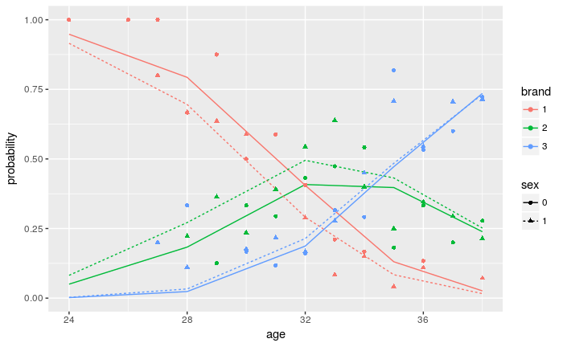

```r
ggplot(probs.long,aes(x=age,y=probability,
  colour=brand,shape=sex))+
  geom_line(aes(linetype=sex))+
  geom_point(data=brands,aes(y=proportion))
```

or note that each proportion is based on a different #obs (in `Freq`), so use different sized points:

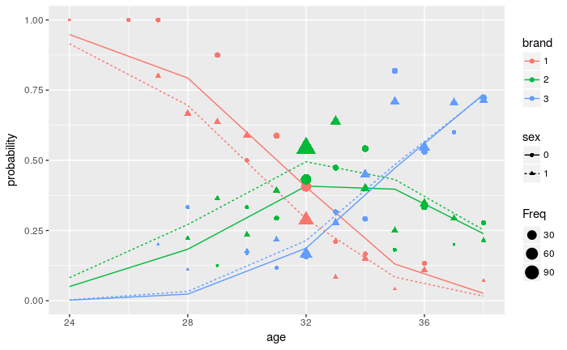

```r
ggplot(probs.long,aes(x=age,y=probability,
  colour=brand,shape=sex))+
  geom_line(aes(linetype=sex))+
  geom_point(data=brands,
             aes(y=proportion,size=Freq))
```